# レポート課題 第6回 課題1

氏名：木澤 祐人  
学籍番号：2094572t

# 準備

## Google Driveのマウントと作業フォルダへの移動

```python
from google.colab import drive
drive.mount('/content/drive')
%cd /content/drive/'My Drive'/情報管理/06/
```

```
/content/drive/My Drive/情報管理/06
```

## 必要ライブラリのインポート

```python
import pandas as pd
import numpy as np
import matplotlib.pyplot as plt
```

## データの読み込みと標準化及びデータのプロット

|  | class | x1 | x2 |
| --- | --- | --- | --- |
| 0 | 1.0 | 1.417 | 5.129 |
| 1 | 0.0 | -1.621 | -0.957 |
| 2 | 1.0 | 1.784 | 6.093 |
| 3 | 0.0 | -1.333 | -0.639 |
| 4 | 1.0 | 0.666 | 5.395 |

```
Nunber of samples: 210
Number of dimensions: 2
Number of classes: 2
```

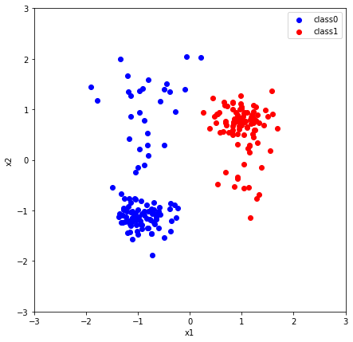

```python
csv_data = pd.read_csv('2class_data_report.csv', encoding='SHIFT-JIS')

display(csv_data.head())

X = csv_data.loc[:, ['x1','x2']].to_numpy()

Y = csv_data.loc[:,'class'].to_numpy()

(num_samples, num_dimensions) = np.shape(X)
print('Nunber of samples: ' + str(num_samples))
print('Number of dimensions: ' + str(num_dimensions))

num_classes = int(np.max(Y) + 1)
print('Number of classes: ' + str(num_classes))

X = (X - np.mean(X, axis=0)) / np.std(X, axis=0)

plt.figure(figsize=(7,7))
plt.scatter(X[Y==0,0], X[Y==0,1], c='b', label='class0')
plt.scatter(X[Y==1,0], X[Y==1,1], c='r', label='class1')
plt.xlabel('x1')
plt.ylabel('x2')
plt.legend()
plt.xlim([-3, 3])
plt.ylim([-3, 3])
plt.show()
```

# 線形判別分析とロジスティック回帰

読み込んだデータに対し、  
線形判別分析とロジスティック回帰をそれぞれ適用し、結果の違いについて考察する。

## 線形判別分析

はじめに、線形判別分析を行う。  
まずクラス内分散-クラス間分散比の行列を計算する。

```python
m_all = np.mean(X, axis=0)

cov_inner = np.zeros((num_dimensions, num_dimensions))
for n in range(num_classes):
  X_tmp = X[Y==n]
  m = np.mean(X_tmp, axis=0)
  cov_inner += np.dot((X_tmp-m).T, (X_tmp-m))

cov_intra = np.zeros((num_dimensions, num_dimensions))
for n in range(num_classes):
  X_tmp = X[Y==n]
  num_samples_n, num_dimensions = np.shape(X_tmp)
  m = np.mean(X_tmp, axis=0)

  m_sub = m - m_all
  m_sub = np.reshape(m_sub, (-1,1))
  cov_intra += num_samples_n * np.dot(m_sub, m_sub.T)

J = np.dot(np.linalg.inv(cov_inner), cov_intra)
```

次に、クラス内分散-クラス間分散比行列を固有値分解し，第一固有ベクトルを取り出す。  
その後、元のデータを得られた第一固有ベクトルへ射影し、結果を X_lda に格納する。

```python
eig_val, eig_vec =np.linalg.eig(J)
eig_val = np.real(eig_val)
eig_vec = np.real(eig_vec)

max_id = np.argmax(eig_val)
first_eig_vec = eig_vec[:, max_id]

X_lda = np.dot(X,first_eig_vec)
```

この判別では、X_ldaの値が正ならクラス1，負ならクラス0として2クラス分類を行っている。  
その正解率を調べると次のようになった。

```python
Y_pred = np.zeros(num_samples, dtype=np.int64)
Y_pred[X_lda > 0] = 1

accuracy = 0
for n in range(num_samples):
  if Y_pred[n] == Y[n]:
    accuracy += 1
accuracy = 100.0 * accuracy / num_samples

print('Accuracy = %.3f' % (accuracy))
```

```
Accuracy = 98.571
```

上の結果より、今回のデータの線形判別分析による分類正解率は 98.571 % であることがわかった。

## ロジスティック回帰

続いて、ロジスティック回帰を行う。  
二次元のデータを${\bf x} = [x_1, x_2]$としたとき，ロジスティック回帰は以下の式になる。  
$\hat{y} = \frac{1}{1+e^{-z}}$  
$z = w_0 + w_1x_1 + w_2x_2$

$z$の式については，${\bf w} = [w_0, w_1, w_2]$，${\bf x}_{\rm mod} = [1, x_1, x_2]^{T}$と置くことで，  
$z = {\bf w}{\bf x}_{\rm mod}$  
とも書ける。  
以下のソースコードではこの書き方を使うことで，実装をシンプルにしている。

まず，$\bf w$ の初期値を決める。  
切片の初期値は 0 とし、データの各次元に関する重みの成分は正規分布に従う乱数で決める。

```python
np.random.seed(0)

initial_w = np.append(0, np.random.randn(num_dimensions))

print('w = ' + str(initial_w))
```

```
w = [0.         1.76405235 0.40015721]
```

次に、1サンプルデータに対してロジスティック回帰を行う関数を以下に定義する。

シグモイド関数の定義  
${\rm sigmoid}(z) = \frac{1}{1+e^{-z}}$  
ロジスティック回帰の定義  
$\hat{y} = sigmoid(z)$  
$z = w_0 + w_1x_1 + w_2x_2 + \dots = [w_0, w_1, w_2, \dots][1, x_1, x_2, \dots]^{T}$

```python
def sigmoid(z):
  return (1+np.exp(-1*z))**(-1)
```

```python
def logistic_regression(x, w):
  x_mod = np.append(1, x)

  z = np.dot(w, x_mod)

  y_hat = sigmoid(z)

  return y_hat
```

この logistic_regression(x, w) にサンプルデータと係数を渡すことにより、  
そのデータに対応する識別結果が 0 から 1 までの連続値スコアとして出力される。  
なお、$\hat{y} > 0.5$の場合はクラス1，$\hat{y} \leq 0.5$の場合はクラス0と識別する。

続いて、勾配を計算する関数を以下に定義する。  
$\frac{\partial L_{mse}}{\partial \bf w} = (\hat{y} - y)(1 - \hat{y})\hat{y}[1, x_1, x_2, \dots]$

```python
def calc_gradient(y_hat, y, x):
  x_mod = np.append(1, x)

  gradient = (y_hat - y)*(1 - y_hat)*y_hat * x_mod

  return gradient
```

この関数 calcgradient で勾配を計算し、  
${\bf w}{\rm next} = {\bf w} - \mu \frac{\partial L_{mse}}{\partial \bf w}$により，${\bf w}$を更新する。 なお、 更新は 50 エポック分 行い、 学習率を $\mu = 0.2$ とする。

```python
from matplotlib import animation, rc
from IPython.display import HTML

np.random.seed(0)

lr = 0.2

w = initial_w.copy()

fig = plt.figure(figsize=(7,7))
plt.scatter(X[Y==0,0], X[Y==0,1], c='b', label='class1')
plt.scatter(X[Y==1,0], X[Y==1,1], c='r', label='class2')
images = []

mse_history = np.array([])

x1 = np.linspace(-3, 3)
x2 = -1.0 * (initial_w[0] + initial_w[1]*x1) / initial_w[2]

for epoch in range(50):

  shuffle_index = np.random.permutation(np.arange(num_samples))
  X_tmp = X[(shuffle_index)]
  Y_tmp = Y[(shuffle_index)]

  mse = 0
  for n in range(num_samples):
    x = X_tmp[n,:]
    y = Y_tmp[n]

    y_hat = logistic_regression(x, w)

    grad = calc_gradient(y_hat, y, x)


    if n % 400 == 0:
      x2 = -1.0 * (w[0] + w[1]*x1) / w[2]
      img = plt.plot(x1, x2, c='b')
      img.append(plt.text(-2.8, 2.5, 'epoch: '+str(epoch), size='x-large'))
      images.append(img)

    w -= lr * grad

    mse += (y - y_hat)**2

  mse /= num_samples
  mse_history = np.append(mse_history, mse)
  print('%d-th epoch: mean square error = %.3f' % (epoch+1, mse))

plt.legend()
plt.xlim([-3, 3])
plt.ylim([-3, 3])

anim = animation.ArtistAnimation(fig, images, interval=100)
rc('animation', html='jshtml')
plt.close()
display(anim)
```

```
1-th epoch: mean square error = 0.026
2-th epoch: mean square error = 0.019
3-th epoch: mean square error = 0.016
4-th epoch: mean square error = 0.014
5-th epoch: mean square error = 0.012
6-th epoch: mean square error = 0.011
7-th epoch: mean square error = 0.010
8-th epoch: mean square error = 0.010
9-th epoch: mean square error = 0.009
10-th epoch: mean square error = 0.009
11-th epoch: mean square error = 0.008
12-th epoch: mean square error = 0.008
13-th epoch: mean square error = 0.008
14-th epoch: mean square error = 0.007
15-th epoch: mean square error = 0.007
16-th epoch: mean square error = 0.007
17-th epoch: mean square error = 0.007
18-th epoch: mean square error = 0.006
19-th epoch: mean square error = 0.006
20-th epoch: mean square error = 0.006
21-th epoch: mean square error = 0.006
22-th epoch: mean square error = 0.006
23-th epoch: mean square error = 0.006
24-th epoch: mean square error = 0.006
25-th epoch: mean square error = 0.005
26-th epoch: mean square error = 0.005
27-th epoch: mean square error = 0.005
28-th epoch: mean square error = 0.005
29-th epoch: mean square error = 0.005
30-th epoch: mean square error = 0.005
31-th epoch: mean square error = 0.005
32-th epoch: mean square error = 0.005
33-th epoch: mean square error = 0.005
34-th epoch: mean square error = 0.005
35-th epoch: mean square error = 0.005
36-th epoch: mean square error = 0.005
37-th epoch: mean square error = 0.004
38-th epoch: mean square error = 0.004
39-th epoch: mean square error = 0.004
40-th epoch: mean square error = 0.004
41-th epoch: mean square error = 0.004
42-th epoch: mean square error = 0.004
43-th epoch: mean square error = 0.004
44-th epoch: mean square error = 0.004
45-th epoch: mean square error = 0.004
46-th epoch: mean square error = 0.004
47-th epoch: mean square error = 0.004
48-th epoch: mean square error = 0.004
49-th epoch: mean square error = 0.004
50-th epoch: mean square error = 0.004
```

[figure not shown]

最後に、線形判別分析同様、  
得られたパラメータを用いた識別結果の正解率を求めると次のようになる。

```python
accuracy = 0

for n in range(num_samples):
  x = X[n,:]
  y = Y[n]
  y_hat = logistic_regression(x, w)

  if y_hat > 0.5 and y == 1:
    accuracy += 1
  elif y_hat <= 0.5 and y == 0:
    accuracy += 1

accuracy = 100.0 * accuracy / num_samples

print('Accuracy = %.3f' % (accuracy))
```

```
Accuracy = 100.000
```

上の結果より、ロジスティック回帰によるクラスタリングでは、  
100 % の割合で正しく判別できることが分かった。

# 考察

それぞれの結果の精度の違いが分類正解率に表れており、  
今回のデータでは  
線形判別分析よりもロジスティック回帰の方がより高い精度で判別ができると言える。

このような違いが生じる主な要因は、 線形判別分析は変数が正規分布に従うことを要求するのに対し、 ロジスティック回帰はその必要がない点にあると考えられる。

実際、次のように各変数ごとの値のヒストグラムから見ても、正規分布に従っていないのは明らかである。

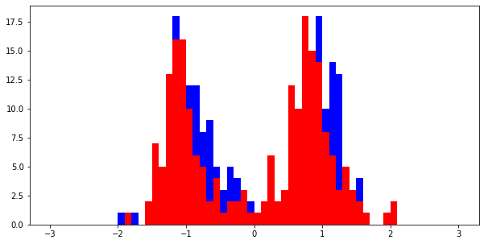

```python
plt.figure(figsize=(10,5))

plt.hist(X[:,0], bins=60, range=(-3, 3), color='b')
plt.hist(X[:,1], bins=60, range=(-3, 3), color='r')

plt.show()
```

また  
ロジスティック回帰分析は  
それぞれのデータの結果が連続値で出力されるため各データが識別境界にどれだけ近いか定量的にわかることに加え、  
係数により各独立変数がどの程度判別に寄与しているか個別に分析することが可能である。

したがって、  
単なる判別だけでなく各変数の評価も目的とする場合には  
ロジスティック回帰分析を優先して行うべきだと言える。